# Capstone Project: Create a Customer Segmentation Report for Arvato Financial Services

In this project, you will analyze demographics data for customers of a mail-order sales company in Germany, comparing it against demographics information for the general population. You'll use unsupervised learning techniques to perform customer segmentation, identifying the parts of the population that best describe the core customer base of the company. Then, you'll apply what you've learned on a third dataset with demographics information for targets of a marketing campaign for the company, and use a model to predict which individuals are most likely to convert into becoming customers for the company. The data that you will use has been provided by our partners at Bertelsmann Arvato Analytics, and represents a real-life data science task.

If you completed the first term of this program, you will be familiar with the first part of this project, from the unsupervised learning project. The versions of those two datasets used in this project will include many more features and has not been pre-cleaned. You are also free to choose whatever approach you'd like to analyzing the data rather than follow pre-determined steps. In your work on this project, make sure that you carefully document your steps and decisions, since your main deliverable for this project will be a blog post reporting your findings.

```python
import numpy as np
import pandas as pd
import matplotlib.pyplot as plt
import seaborn as sns

# preprocessing
import sklearn
from sklearn.cluster import KMeans
from sklearn.decomposition import PCA
from sklearn.preprocessing import MinMaxScaler
from sklearn.preprocessing import QuantileTransformer

from sklearn.model_selection import train_test_split, GridSearchCV

# unsupervised modelling
from sklearn import cluster
from sklearn.cluster import AffinityPropagation
from sklearn.ensemble import GradientBoostingRegressor

# cleaning
import gc
# export mode
import pickle

# magic word for producing visualizations in notebook
%matplotlib inline

from keras.models import Sequential
from keras.layers import Dense, Activation, BatchNormalization, Dropout
from keras.initializers import random_normal
from keras.callbacks import ModelCheckpoint, LearningRateScheduler
from keras.optimizers import SGD

import keras
from keras import backend as K

from keras.models import load_model
import tensorflow as tf
```

```python
from arvato_project import *
from arvato_project_preprocessing import *
```

# 1. understanding the data

The data dictionary helps to understand how data is grouped, supporting future decisions about how to cluster the information about the observation.

```python
header_cols = ['Attribute', 'Value', 'Meaning']
values = pd.read_excel('DIAS Information Levels - Attributes 2017.xlsx', sheet_name='attribute_values')[header_cols]
values.columns = ['attribute', 'value', 'meaning']

values = values.fillna(method='ffill')
```

```python
header_cols = ['Information level', 'Attribute', 'Description', 'Additional notes']
attributes = pd.read_excel('DIAS Information Levels - Attributes 2017.xlsx', sheet_name='Komplett_v2')[header_cols]
attributes.columns = ['information', 'attribute', 'description', 'notes']

attributes['information'] = attributes['information'].fillna(method='ffill').fillna(method='bfill')
```

```python
df_attributes = attributes.merge(values, on='attribute', how='outer')
df_attributes.head()
```

|  | information | attribute | description | notes | value | meaning |
| --- | --- | --- | --- | --- | --- | --- |
| 0 | Person | AGER_TYP | best-ager typology | in cooperation with Kantar TNS; the informatio... | -1 | unknown |
| 1 | Person | AGER_TYP | best-ager typology | in cooperation with Kantar TNS; the informatio... | 0 | no classification possible |
| 2 | Person | AGER_TYP | best-ager typology | in cooperation with Kantar TNS; the informatio... | 1 | passive elderly |
| 3 | Person | AGER_TYP | best-ager typology | in cooperation with Kantar TNS; the informatio... | 2 | cultural elderly |
| 4 | Person | AGER_TYP | best-ager typology | in cooperation with Kantar TNS; the informatio... | 3 | experience-driven elderly |

### information level categories

```python
print('information level: \n', df_attributes['information'].unique())
```

```
information level:
 ['Person' 'Household' 'Building' 'Microcell (RR4_ID)' 'Microcell (RR3_ID)'
 '125m x 125m Grid' 'Postcode' 'RR1_ID' 'PLZ8' 'Community' nan]
```

```python
df_attributes.groupby('information').count()[['attribute']]
```

| information | attribute |
| --- | --- |
| 125m x 125m Grid | 264 |
| Building | 51 |
| Community | 19 |
| Household | 298 |
| Microcell (RR3_ID) | 317 |
| Microcell (RR4_ID) | 131 |
| PLZ8 | 766 |
| Person | 340 |
| Postcode | 25 |
| RR1_ID | 30 |

## Part 0: Get to Know the Data

Each row of the demographics files represents a single person, but also includes information outside of individuals, including information about their household, building, and neighborhood. Use the information from the first two files to figure out how customers ("CUSTOMERS") are similar to or differ from the general population at large ("AZDIAS"), then use your analysis to make predictions on the other two files ("MAILOUT"), predicting which recipients are most likely to become a customer for the mail-order company.

The "CUSTOMERS" file contains three extra columns (**'CUSTOMER_GROUP', 'ONLINE_PURCHASE', and 'PRODUCT_GROUP'**), which provide broad information about the customers depicted in the file. The original "MAILOUT" file included one additional column, "RESPONSE", which indicated whether or not each recipient became a customer of the company. For the "TRAIN" subset, this column has been retained, but in the "TEST" subset it has been removed; it is against that withheld column that your final predictions will be assessed in the Kaggle competition.

Otherwise, all of the remaining columns are the same between the three data files. For more information about the columns depicted in the files, you can refer to two Excel spreadsheets provided in the workspace. One of them is a top-level list of attributes and descriptions, organized by informational category. The other is a detailed mapping of data values for each feature in alphabetical order.

In the below cell, we've provided some initial code to load in the first two datasets. Note for all of the `.csv` data files in this project that they're semicolon (`;`) delimited, so an additional argument in the [`read_csv()`](https://pandas.pydata.org/pandas-docs/stable/generated/pandas.read_csv.html) call has been included to read in the data properly. Also, considering the size of the datasets, it may take some time for them to load completely.

You'll notice when the data is loaded in that a warning message will immediately pop up. Before you really start digging into the modeling and analysis, you're going to need to perform some cleaning. Take some time to browse the structure of the data and look over the informational spreadsheets to understand the data values. Make some decisions on which features to keep, which features to drop, and if any revisions need to be made on data formats. It'll be a good idea to create a function with pre-processing steps, since you'll need to clean all of the datasets before you work with them.

```python
# load in the data
#azdias = pd.read_csv('../../data/Term2/capstone/arvato_data/Udacity_AZDIAS_052018.csv', sep=';')
#customers = pd.read_csv('../../data/Term2/capstone/arvato_data/Udacity_CUSTOMERS_052018.csv', sep=';')

df_population = pd.read_csv('Udacity_AZDIAS_052018.csv', sep=';')
df_customers = pd.read_csv('Udacity_CUSTOMERS_052018.csv', sep=';')
```

```
D:\Programas\Anaconda3\lib\site-packages\IPython\core\interactiveshell.py:3072: DtypeWarning: Columns (18,19) have mixed types.Specify dtype option on import or set low_memory=False.
  interactivity=interactivity, compiler=compiler, result=result)
```

```python
print('shape: ')
print('   - Germany population: ', df_population.shape)
print('   - customers of a mail-order company: ', df_customers.shape)
```

```
shape:
   - Germany population:  (891221, 366)
   - customers of a mail-order company:  (191652, 369)
```

```python
print('len azdias:   ', len(df_population.LNR.unique()))
print('len customers:', len(df_customers.LNR.unique()))

# LNR: id of each row
assert len(df_population.LNR.unique()) == df_population.shape[0]
assert len(df_customers.LNR.unique()) == df_customers.shape[0]
```

```
len azdias:    891221
len customers: 191652
```

```python
print('features exclusive of customer information: ', set(df_customers) - set(df_population))
```

```
features exclusive of customer information:  {'PRODUCT_GROUP', 'ONLINE_PURCHASE', 'CUSTOMER_GROUP'}
```

```python
df_customers[['CUSTOMER_GROUP', 'ONLINE_PURCHASE', 'PRODUCT_GROUP']].sample(10)
```

|  | CUSTOMER_GROUP | ONLINE_PURCHASE | PRODUCT_GROUP |
| --- | --- | --- | --- |
| 64792 | MULTI_BUYER | 0 | COSMETIC_AND_FOOD |
| 153142 | MULTI_BUYER | 0 | COSMETIC_AND_FOOD |
| 95440 | MULTI_BUYER | 0 | COSMETIC_AND_FOOD |
| 183145 | SINGLE_BUYER | 0 | COSMETIC |
| 99323 | MULTI_BUYER | 1 | COSMETIC |
| 128340 | MULTI_BUYER | 1 | COSMETIC_AND_FOOD |
| 137715 | SINGLE_BUYER | 0 | FOOD |
| 109902 | SINGLE_BUYER | 0 | FOOD |
| 144698 | MULTI_BUYER | 0 | COSMETIC_AND_FOOD |
| 9692 | SINGLE_BUYER | 1 | FOOD |

```python
# not interested in specific individual
df_population = df_population.drop(['LNR'], axis='columns')
df_customers = df_customers.drop(['LNR', 'CUSTOMER_GROUP', 'ONLINE_PURCHASE', 'PRODUCT_GROUP'], axis='columns')

gc.collect();
```

```python
# not interested in duplicated individuals (individual with similar caracteristics)
df_population = df_population.drop_duplicates()
df_customers = df_customers.drop_duplicates()

gc.collect();
```

```python
df_attributes = df_attributes[df_attributes['attribute'].isin(df_population.columns)]
df_attributes.head()
```

|  | information | attribute | description | notes | value | meaning |
| --- | --- | --- | --- | --- | --- | --- |
| 0 | Person | AGER_TYP | best-ager typology | in cooperation with Kantar TNS; the informatio... | -1 | unknown |
| 1 | Person | AGER_TYP | best-ager typology | in cooperation with Kantar TNS; the informatio... | 0 | no classification possible |
| 2 | Person | AGER_TYP | best-ager typology | in cooperation with Kantar TNS; the informatio... | 1 | passive elderly |
| 3 | Person | AGER_TYP | best-ager typology | in cooperation with Kantar TNS; the informatio... | 2 | cultural elderly |
| 4 | Person | AGER_TYP | best-ager typology | in cooperation with Kantar TNS; the informatio... | 3 | experience-driven elderly |

### information level and attributes

The data dictionnary is out of date, some infomartion about some features are not provided.

After carefully understanding the data, we propose the follow distribution. Future improve in future models, could start in how attributes are grouped in each information level.

```python
grid_125 = get_attributes_list(information_level='125m x 125m Grid', attributes_description=df_attributes)
building = get_attributes_list(information_level='Building', attributes_description=df_attributes)
community = get_attributes_list(information_level='Community', attributes_description=df_attributes)
household = get_attributes_list(information_level='Household', attributes_description=df_attributes)
microcell_rr3 = get_attributes_list(information_level='Microcell (RR3_ID)', attributes_description=df_attributes)
microcell_rr4 = get_attributes_list(information_level='Microcell (RR4_ID)', attributes_description=df_attributes)
plz8 = get_attributes_list(information_level='PLZ8', attributes_description=df_attributes)
person = get_attributes_list(information_level='Person', attributes_description=df_attributes)
postcode = get_attributes_list(information_level='Postcode', attributes_description=df_attributes)
rr1 = get_attributes_list(information_level='RR1_ID', attributes_description=df_attributes)
```

```python
attributes_list = grid_125 + building + community + household + \
                    microcell_rr3 + microcell_rr4 + plz8 + person + postcode + rr1
```

```python
assert len(set(attributes_list) - set(df_population.columns)) == 0
```

```python
processing_steps = {
                    'Person':{'df_columns':person},
                    'Household':{'df_columns':household},
                    'Building':{'df_columns':building},
                    'Microcell (RR4_ID)':{'df_columns':microcell_rr4},
                    'Microcell (RR3_ID)':{'df_columns':microcell_rr3},
                    '125m x 125m Grid':{'df_columns':grid_125},
                    'Postcode':{'df_columns':postcode},
                    'RR1_ID':{'df_columns':rr1},
                    'PLZ8':{'df_columns':plz8},
                    'Community':{'df_columns':community}
                   }
```

```
--------------------------------------------------
Person
```

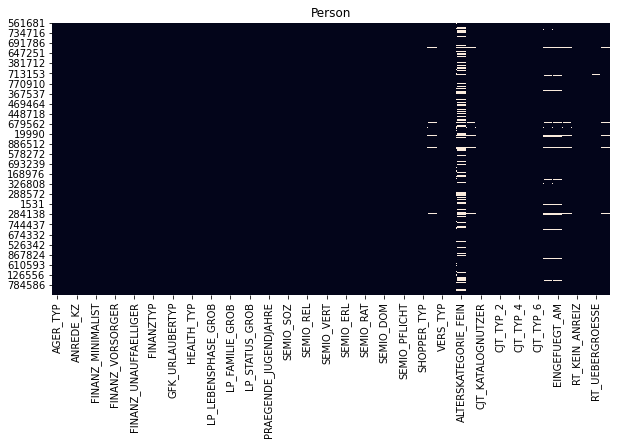

```
--------------------------------------------------
Household
```

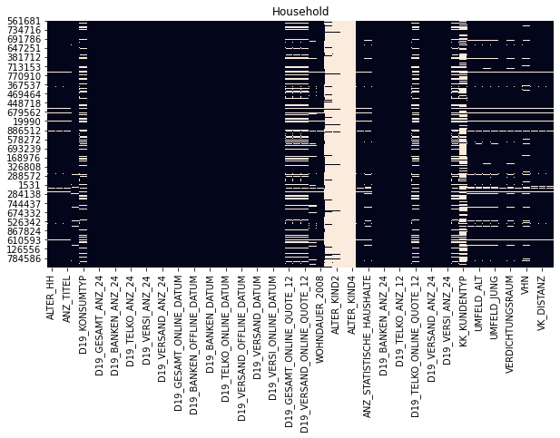

```
--------------------------------------------------
Building
```

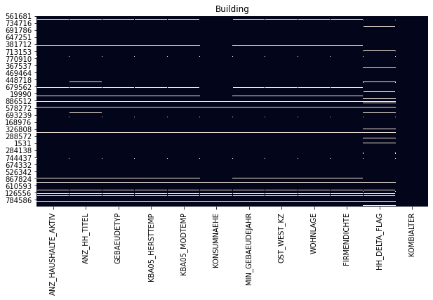

```
--------------------------------------------------
Microcell (RR4_ID)
```

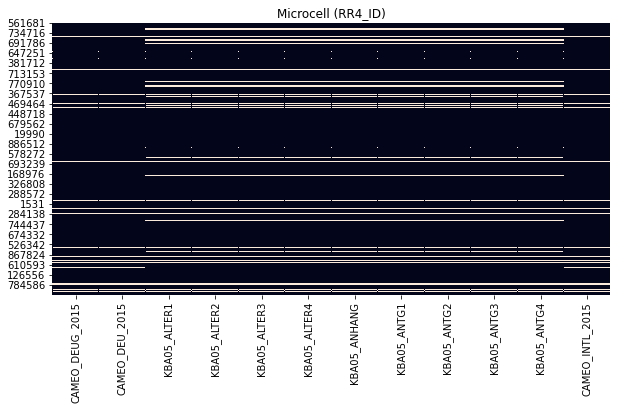

```
--------------------------------------------------
Microcell (RR3_ID)
```

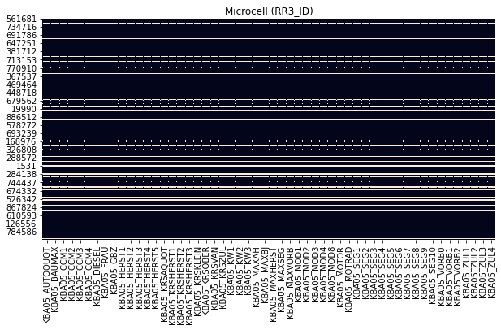

```
--------------------------------------------------
125m x 125m Grid
```

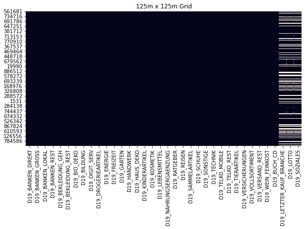

```
--------------------------------------------------
Postcode
```

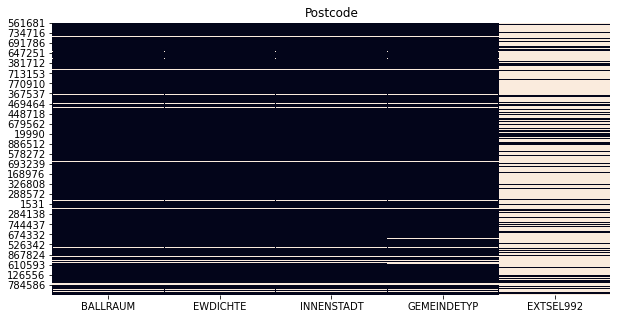

```
--------------------------------------------------
RR1_ID
```

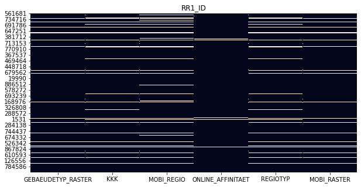

```
--------------------------------------------------
PLZ8
```

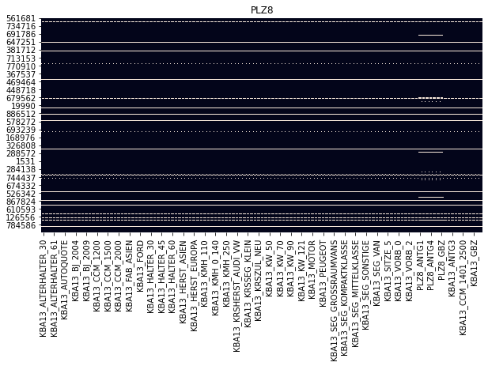

```
--------------------------------------------------
Community
```

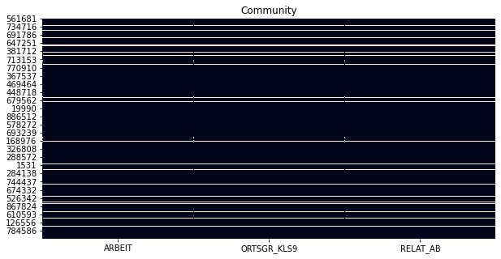

```python
for information_level in processing_steps.keys():
    print('-'*50)
    print(information_level)
    attr = processing_steps[information_level]['df_columns']
    plot_heatmap_isna(attr, information_level, df_population.sample(25000, random_state=42))
```

Each of the heatmaps above shows that, in general, we know consistently know (or not know) the same groups of information about the same group of observations. This process reveals how consistent each information level is in terms of grouping attributes of each observation.

In this approach, we consider that not knowing about certain observation attribute is already an information. Therefore, after considering some exceptions, we may not drop attributes with missing values. Instead, we may fill with an appropriate data to inform that the observation is unknown. Categorical data, that could not be ordered, we get dummies to support modelling.

## Part 1: Customer Segmentation Report

The main bulk of your analysis will come in this part of the project. Here, you should use unsupervised learning techniques to describe the relationship between the demographics of the company's existing customers and the general population of Germany. By the end of this part, you should be able to describe parts of the general population that are more likely to be part of the mail-order company's main customer base, and which parts of the general population are less so.

### preprocessing functions

The following functions consider the type of each attribute, as part of each information level. The goal is determine data type for the next step, modelling.

```python
X_population, process_steps = preprocess_all(df_population, processing_steps)
```

```python
X_customer, _ = preprocess_all(df_customers, processing_steps)
```

```python
df_population = None
df_customer = None
gc.collect()

X_population.to_csv('population_preprocessed.csv', sep=';', index=False)
X_customer.to_csv('customer_preprocessed.csv', sep=';', index=False)
```

```python
gc.collect()
```

```
883
```

```python
X_population = pd.read_csv('population_preprocessed.csv', sep=';')
X_customer = pd.read_csv('customer_preprocessed.csv', sep=';')
```

```python
cols_populationExclusive = list(set(X_population.columns) - set(X_customer.columns))
cols_customerExclusive = list(set(X_customer.columns) - set(X_population.columns))

if len(cols_populationExclusive) != 0:
    for col in cols_populationExclusive:
        X_customer[col] = 0.
if len(cols_customerExclusive) != 0:
    for col in cols_populationExclusive:
        X_population[col] = 0.
```

```python
qt = QuantileTransformer(n_quantiles=200, random_state=0, output_distribution='normal')
qt.fit(X_population)

min_max = MinMaxScaler()
min_max.fit(qt.transform(X_population))

pca = PCA(n_components=int(2), whiten=True)
pca.fit(min_max.transform(qt.transform(X_population)))

m_population = pca.transform(min_max.transform(qt.transform(X_population)))
m_customer = pca.transform(min_max.transform(qt.transform(X_customer)))
```

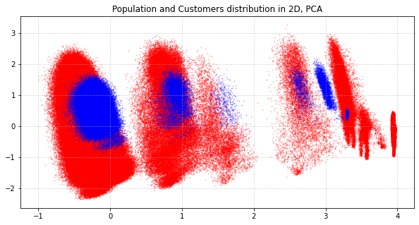

```python
plt.figure(figsize=(10,5))
plt.scatter(m_population[:, 0], m_population[:, 1], s=0.75, alpha=0.25, color='red')
plt.scatter(m_customer[:, 0], m_customer[:, 1], s=0.75, alpha=0.25, color='blue')

plt.title('Population and Customers distribution in 2D, PCA')
plt.grid(ls='--', alpha=0.5)
plt.show()
```

```python
qt = QuantileTransformer(n_quantiles=200, random_state=0, output_distribution='normal')
qt.fit(X_population)
min_max = MinMaxScaler()
min_max.fit(qt.transform(X_population))
pca = PCA(whiten=True)
pca.fit(min_max.transform(qt.transform(X_population)))
```

```
323 out of 765 features explain 95% of data variance
```

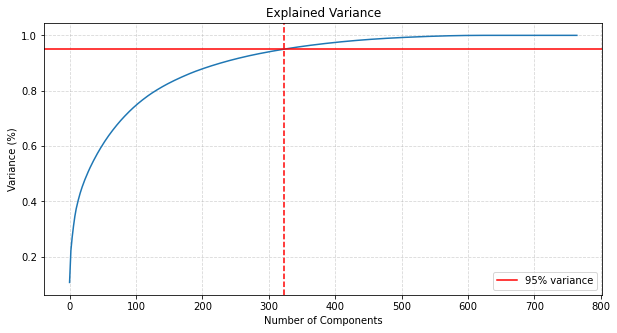

```python
num_features = X_population.shape[1] - np.sum(np.cumsum(pca.explained_variance_ratio_) >= 0.95)
print('{} out of {} features explain 95% of data variance'.format(num_features, X_population.shape[1]))

plt.figure(figsize=(10, 5))
plt.plot(np.cumsum(pca.explained_variance_ratio_))
plt.axhline(y=0.95, color='red', label='95% variance')
plt.axvline(x=num_features, color='red', ls='--')
plt.xlabel('Number of Components')
plt.ylabel('Variance (%)')
plt.title('Explained Variance')
plt.grid(ls='--', alpha=0.5)
plt.legend(loc='lower right')
plt.show()
```

```python
m_population = None
m_customer = None

qt = QuantileTransformer(n_quantiles=200, random_state=0, output_distribution='normal')
qt.fit(X_population)

min_max = MinMaxScaler()
min_max.fit(qt.transform(X_population))

pca = PCA(n_components=num_features, whiten=True)
pca.fit(min_max.transform(qt.transform(X_population)))

m_population = pca.transform(min_max.transform(qt.transform(X_population)))
m_customer = pca.transform(min_max.transform(qt.transform(X_customer)))
```

```python
assert m_population.shape[1] == m_customer.shape[1]
```

```python
m_population = pd.DataFrame(m_population)
m_customer = pd.DataFrame(m_customer)
```

```python
m_population.to_csv('m_population.csv', sep=';', index=False)
m_customer.to_csv('m_customer.csv', sep=';', index=False)
```

```python
gc.collect()
```

```
955
```

```python
m_population = pd.read_csv('m_population.csv', sep=';')
m_customer = pd.read_csv('m_customer.csv', sep=';')
```

```python
m_population = m_population.drop_duplicates()
m_customer = m_customer.drop_duplicates()
```

```python
gc.collect()
```

```
509
```

```python
aprop = AffinityPropagation(max_iter=1000, convergence_iter=25, damping=0.5, preference=None)
aprop.fit(m_population.sample(int(m_population.shape[0]*0.01), random_state=42).values)
```

```
AffinityPropagation(affinity='euclidean', convergence_iter=25, copy=True,
                    damping=0.5, max_iter=1000, preference=None, verbose=False)
```

```python
mPopulation_aprop_pred = aprop.predict(m_population)
mCustomer_aprop_pred = aprop.predict(m_customer)
```

```python
mPopulation_aprop_pred = pd.Series(mPopulation_aprop_pred)
mCustomer_aprop_pred = pd.Series(mCustomer_aprop_pred)
```

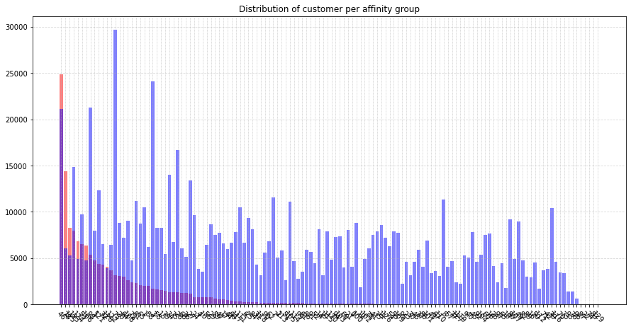

```python
plt.figure(figsize=(15, 7.5))
customer_ValueCounts = mCustomer_aprop_pred.value_counts()
population_ValueCounts = mPopulation_aprop_pred.value_counts()


plt.bar(x=customer_ValueCounts.index.astype(str),
        height=customer_ValueCounts.values, color='blue', alpha=0.5)
plt.bar(x=population_ValueCounts.index.astype(str),
        height=population_ValueCounts.values, color='red', alpha=0.5)

plt.title('Distribution of customer per affinity group')
plt.xticks(rotation=-45)
plt.grid(ls='--', alpha=0.5)
plt.show()
```

```python
class_translate = {}
for i, class_ap in enumerate(customer_ValueCounts.index):
    class_translate[class_ap] = i

class_translate
```

```
{46: 0,
 78: 1,
 125: 2,
 123: 3,
 124: 4,
 53: 5,
 106: 6,
 98: 7,
 5: 8,
 121: 9,
 32: 10,
 128: 11,
 122: 12,
 73: 13,
 20: 14,
```

[output cut: 103 more lines]

## Part 2: Supervised Learning Model

Now that you've found which parts of the population are more likely to be customers of the mail-order company, it's time to build a prediction model. Each of the rows in the "MAILOUT" data files represents an individual that was targeted for a mailout campaign. Ideally, we should be able to use the demographic information from each individual to decide whether or not it will be worth it to include that person in the campaign.

The "MAILOUT" data has been split into two approximately equal parts, each with almost 43 000 data rows. In this part, you can verify your model with the "TRAIN" partition, which includes a column, "RESPONSE", that states whether or not a person became a customer of the company following the campaign. In the next part, you'll need to create predictions on the "TEST" partition, where the "RESPONSE" column has been withheld.

```python
# mailout_train = pd.read_csv('../../data/Term2/capstone/arvato_data/Udacity_MAILOUT_052018_TRAIN.csv', sep=';')
mailout_train = pd.read_csv('Udacity_MAILOUT_052018_TRAIN.csv', sep=';')
```

```python
df_train = mailout_train.drop_duplicates()
```

```python
X = df_train.sort_values('RESPONSE', ascending=False).drop('RESPONSE', axis='columns').set_index('LNR')
y = df_train[['LNR', 'RESPONSE']].set_index('LNR')

X = X.drop_duplicates(keep='first')
y = y.loc[X.index]
```

```python
X.head()
```

| LNR | AGER_TYP | AKT_DAT_KL | ALTER_HH | ALTER_KIND1 | ALTER_KIND2 | ALTER_KIND3 | ALTER_KIND4 | ALTERSKATEGORIE_FEIN | ANZ_HAUSHALTE_AKTIV | ANZ_HH_TITEL | ... | VHN | VK_DHT4A | VK_DISTANZ | VK_ZG11 | W_KEIT_KIND_HH | WOHNDAUER_2008 | WOHNLAGE | ZABEOTYP | ANREDE_KZ | ALTERSKATEGORIE_GROB |
| --- | --- | --- | --- | --- | --- | --- | --- | --- | --- | --- | --- | --- | --- | --- | --- | --- | --- | --- | --- | --- | --- |
| 53559 | 2 | 1.0 | 20.0 | NaN | NaN | NaN | NaN | 8.0 | 1.0 | 0.0 | ... | 1.0 | 2.0 | 1.0 | 2.0 | 2.0 | 9.0 | 7.0 | 3 | 2 | 4 |
| 43375 | -1 | NaN | NaN | NaN | NaN | NaN | NaN | NaN | NaN | NaN | ... | NaN | NaN | NaN | NaN | NaN | NaN | NaN | 3 | 1 | 1 |
| 16198 | 2 | 1.0 | 15.0 | NaN | NaN | NaN | NaN | 9.0 | 1.0 | 0.0 | ... | 3.0 | 3.0 | 5.0 | 3.0 | 5.0 | 9.0 | 2.0 | 2 | 2 | 4 |
| 77621 | 2 | 1.0 | 9.0 | NaN | NaN | NaN | NaN | 7.0 | 2.0 | 0.0 | ... | 0.0 | 1.0 | 2.0 | 1.0 | 6.0 | 9.0 | 1.0 | 1 | 2 | 4 |
| 20316 | -1 | 1.0 | 14.0 | NaN | NaN | NaN | NaN | 14.0 | 6.0 | 0.0 | ... | 1.0 | 8.0 | 8.0 | 5.0 | 4.0 | 9.0 | 2.0 | 4 | 1 | 3 |

5 rows × 365 columns

```python
X, _ = preprocess_all(X, processing_steps)
```

```python
if len(cols_populationExclusive) != 0:
    for col in cols_populationExclusive:
        X[col] = 0.
if len(cols_customerExclusive) != 0:
    for col in cols_populationExclusive:
        X[col] = 0.
```

```python
X.shape
```

```
(37195, 765)
```

```python
m = pca.transform(min_max.transform(qt.transform(X)))
```

```python
m = pd.DataFrame(m)
```

```python
m.head()
```

|  | 0 | 1 | 2 | 3 | 4 | 5 | 6 | 7 | 8 | 9 | ... | 313 | 314 | 315 | 316 | 317 | 318 | 319 | 320 | 321 | 322 |
| --- | --- | --- | --- | --- | --- | --- | --- | --- | --- | --- | --- | --- | --- | --- | --- | --- | --- | --- | --- | --- | --- |
| 0 | -0.178038 | 0.886170 | 0.457676 | 0.486014 | 0.254193 | -0.815651 | -0.575489 | -0.156411 | -0.319821 | -0.406363 | ... | 3.602649 | 4.631608 | 0.284860 | 1.844723 | -1.733637 | 0.975474 | -0.657893 | 0.455802 | -1.872015 | -1.055367 |
| 1 | 3.296861 | 0.453554 | 0.134158 | 0.490970 | -0.129888 | -0.081662 | -0.279012 | 1.162390 | 1.315333 | -0.279030 | ... | 0.859660 | -0.517338 | -0.765767 | -0.836135 | 0.112009 | 1.009312 | 1.095284 | 1.650766 | -0.251760 | 0.880848 |
| 2 | -0.186921 | 0.697559 | 0.159278 | 0.415781 | 0.545311 | -0.185013 | -0.718874 | 0.200180 | -0.207734 | -0.508957 | ... | -0.300530 | 1.410434 | 1.856611 | 2.278011 | -1.470374 | -0.581126 | -0.631350 | 3.179586 | -3.433330 | 3.863907 |
| 3 | -0.085754 | 0.662052 | 0.298289 | 0.360808 | -0.036492 | -0.477505 | -0.276249 | 0.296589 | -0.548078 | -0.457794 | ... | -0.353515 | 1.107365 | -0.322157 | 1.235737 | 1.655827 | -0.184993 | -0.269522 | 2.693156 | -3.185824 | 1.057727 |
| 4 | 0.006624 | 0.363806 | -0.023632 | -0.001712 | -0.137516 | 0.073140 | -0.641134 | 0.390095 | 0.138113 | 0.016661 | ... | 0.601663 | -0.415087 | -2.545090 | -1.321398 | 1.955418 | -1.161862 | 0.674994 | 0.143035 | -2.758593 | -0.021204 |

5 rows × 323 columns

```python
gc.collect()
```

```
327
```

```python
m[323] = aprop.predict(m)
```

```python
m[323] = m[323].replace(class_translate)
```

```python
X_train, X_val, y_train, y_val = train_test_split(m, y, test_size=0.2, random_state=42, stratify=y)
```

```python
def NN_model(X):

    gc.collect()

    metrics = [
          keras.metrics.TruePositives(name='tp'),
          keras.metrics.FalsePositives(name='fp'),
          keras.metrics.TrueNegatives(name='tn'),
          keras.metrics.FalseNegatives(name='fn'),
          keras.metrics.BinaryAccuracy(name='accuracy'),
          keras.metrics.Precision(name='precision'),
          keras.metrics.Recall(name='recall'),
          keras.metrics.AUC(name='auc'),
    ]

    model = Sequential()
    model.add(Dense(X.shape[1], input_dim=X.shape[1],
                    kernel_initializer=random_normal(mean=0., stddev=0.1)))
    model.add(BatchNormalization())

    model.add(Dense(3*X.shape[1], kernel_initializer=random_normal(mean=0., stddev=0.1),
                activation='sigmoid'))
    model.add(BatchNormalization())
    model.add(Dropout(0.2))
    model.add(Dense(3*X.shape[1], kernel_initializer=random_normal(mean=0., stddev=0.1),
                activation='sigmoid'))
    model.add(BatchNormalization())
    model.add(Dense(3*X.shape[1], kernel_initializer=random_normal(mean=0., stddev=0.1),
                activation='sigmoid'))
    model.add(BatchNormalization())
    model.add(Dropout(0.2))
    model.add(Dense(3*X.shape[1], kernel_initializer=random_normal(mean=0., stddev=0.1),
                activation='sigmoid'))
    model.add(BatchNormalization())
    model.add(Dropout(0.2))
    model.add(Dense(3*X.shape[1], kernel_initializer=random_normal(mean=0., stddev=0.1),
                activation='sigmoid'))
    model.add(BatchNormalization())
    model.add(Dropout(0.2))

    model.add(BatchNormalization())
    model.add(Dense(1, kernel_initializer=random_normal(mean=0., stddev=0.1),
                    activation='sigmoid'))

    sgd = SGD(decay=1e-6, momentum=0.9, nesterov=True)
    model.compile(loss=keras.losses.BinaryCrossentropy(), optimizer='adam', metrics=metrics)

    return model
```

```python
gc.collect()
```

```
6245
```

```python
mmscaleNN = MinMaxScaler()
X_train = mmscaleNN.fit_transform(X_train)
X_val = mmscaleNN.transform(X_val)

filename = "model_01.h5"
checkpoint_filepath = 'models//'+filename
model_checkpoint_callback = ModelCheckpoint(
    filepath=checkpoint_filepath,
    save_weights_only=False,
    monitor='val_auc',
    mode='max',
    save_best_only=True)

model = NN_model(X_train)

model.fit(X_train, y_train, epochs=50, validation_data=(X_val, y_val),
          batch_size=128, verbose=1, class_weight={0: 1., 1: 100.}, callbacks=[model_checkpoint_callback])

#model.save(checkpoint_filepath)
#model = load_model('model.h5')
```

```
Train on 29756 samples, validate on 7439 samples
```

```
<keras.callbacks.callbacks.History at 0x235c10c3d88>
```

```python
gc.collect()
```

```
327
```

```python
filename = "model_01.h5"
checkpoint_filepath = 'models//'+filename
model = NN_model(X_train)
model = load_model(checkpoint_filepath, compile=False)

y_pred_NN = model.predict(X_val)
```

```python
fpr, tpr, thresholds = sklearn.metrics.roc_curve(y_test, y_pred_NN, pos_label=1)
sklearn.metrics.auc(fpr, tpr)
```

```
0.6930670221304897
```

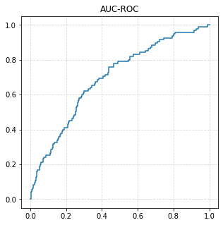

```python
plt.figure(figsize=(5,5))
plt.plot(fpr, tpr)

plt.title('AUC-ROC')
plt.grid(ls='--', alpha=0.5)
plt.show()
```

```python
parameters = {'n_estimators':[50, 100, 200],
              'min_samples_split': [2, 4],
              'learning_rate':[0.05, 0.1]}


model = GradientBoostingRegressor(random_state=42)
gb_model = GridSearchCV(estimator=model, param_grid=parameters, scoring='roc_auc')
gb_model.fit(X_train, y_train)
```

[output not shown]

[output cut: 67 more lines]

[output not shown]

```
GridSearchCV(cv=None, error_score=nan,
             estimator=GradientBoostingRegressor(alpha=0.9, ccp_alpha=0.0,
                                                 criterion='friedman_mse',
                                                 init=None, learning_rate=0.1,
                                                 loss='ls', max_depth=3,
                                                 max_features=None,
                                                 max_leaf_nodes=None,
                                                 min_impurity_decrease=0.0,
                                                 min_impurity_split=None,
                                                 min_samples_leaf=1,
                                                 min_samples_split=2,
                                                 min_weight_fraction_leaf=0.0,
                                                 n_estimators=100,
                                                 n_iter_no_change=None,
                                                 presort='deprecated',
                                                 random_state=42, subsample=1.0,
                                                 tol=0.0001,
                                                 validation_fraction=0.1,
                                                 verbose=0, warm_start=False),
             iid='deprecated', n_jobs=None,
             param_grid={'learning_rate': [0.05, 0.1],
                         'min_samples_split': [2, 4],
                         'n_estimators': [50, 100, 200]},
             pre_dispatch='2*n_jobs', refit=True, return_train_score=False,
             scoring='roc_auc', verbose=0)
```

```python
gb_model.best_params_
```

```
{'learning_rate': 0.1, 'min_samples_split': 2, 'n_estimators': 100}
```

```python
y_pred_GB = gb_model.predict(X_val)
```

```python
y_pred_GB
```

```
array([0.00907641, 0.00660999, 0.00471327, ..., 0.01841895, 0.0201945 ,
       0.00612147])
```

```python
fpr, tpr, thresholds = sklearn.metrics.roc_curve(y_test, y_pred_GB, pos_label=1)
sklearn.metrics.auc(fpr, tpr)
```

```
0.6832523506478615
```

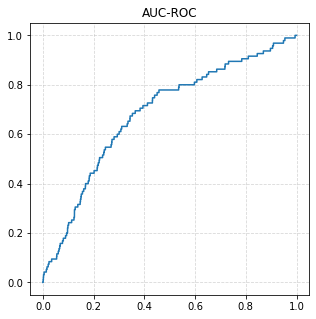

```python
plt.figure(figsize=(5,5))
plt.plot(fpr, tpr)

plt.title('AUC-ROC')
plt.grid(ls='--', alpha=0.5)
plt.show()
```

```python
fpr, tpr, thresholds = sklearn.metrics.roc_curve(y_test, (y_pred_NN.T[0] + y_pred_GB)/2, pos_label=1)
sklearn.metrics.auc(fpr, tpr)
```

```
0.6953288040362344
```

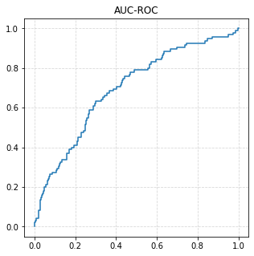

```python
plt.figure(figsize=(5,5))
plt.plot(fpr, tpr)

plt.title('AUC-ROC')
plt.grid(ls='--', alpha=0.5)
plt.show()
```

## Part 3: Kaggle Competition

Now that you've created a model to predict which individuals are most likely to respond to a mailout campaign, it's time to test that model in competition through Kaggle. If you click on the link [here](http://www.kaggle.com/t/21e6d45d4c574c7fa2d868f0e8c83140), you'll be taken to the competition page where, if you have a Kaggle account, you can enter. If you're one of the top performers, you may have the chance to be contacted by a hiring manager from Arvato or Bertelsmann for an interview!

Your entry to the competition should be a CSV file with two columns. The first column should be a copy of "LNR", which acts as an ID number for each individual in the "TEST" partition. The second column, "RESPONSE", should be some measure of how likely each individual became a customer – this might not be a straightforward probability. As you should have found in Part 2, there is a large output class imbalance, where most individuals did not respond to the mailout. Thus, predicting individual classes and using accuracy does not seem to be an appropriate performance evaluation method. Instead, the competition will be using AUC to evaluate performance. The exact values of the "RESPONSE" column do not matter as much: only that the higher values try to capture as many of the actual customers as possible, early in the ROC curve sweep.

```python
# mailout_test = pd.read_csv('../../data/Term2/capstone/arvato_data/Udacity_MAILOUT_052018_TEST.csv', sep=';')
mailout_test = pd.read_csv('Udacity_MAILOUT_052018_TEST.csv', sep=';')
```

```python
mailout_test
```

|  | LNR | AGER_TYP | AKT_DAT_KL | ALTER_HH | ALTER_KIND1 | ALTER_KIND2 | ALTER_KIND3 | ALTER_KIND4 | ALTERSKATEGORIE_FEIN | ANZ_HAUSHALTE_AKTIV | ... | VHN | VK_DHT4A | VK_DISTANZ | VK_ZG11 | W_KEIT_KIND_HH | WOHNDAUER_2008 | WOHNLAGE | ZABEOTYP | ANREDE_KZ | ALTERSKATEGORIE_GROB |
| --- | --- | --- | --- | --- | --- | --- | --- | --- | --- | --- | --- | --- | --- | --- | --- | --- | --- | --- | --- | --- | --- |
| 0 | 1754 | 2 | 1.0 | 7.0 | NaN | NaN | NaN | NaN | 6.0 | 2.0 | ... | 4.0 | 5.0 | 6.0 | 3.0 | 6.0 | 9.0 | 3.0 | 3 | 1 | 4 |
| 1 | 1770 | -1 | 1.0 | 0.0 | NaN | NaN | NaN | NaN | 0.0 | 20.0 | ... | 1.0 | 5.0 | 2.0 | 1.0 | 6.0 | 9.0 | 5.0 | 3 | 1 | 4 |
| 2 | 1465 | 2 | 9.0 | 16.0 | NaN | NaN | NaN | NaN | 11.0 | 2.0 | ... | 3.0 | 9.0 | 6.0 | 3.0 | 2.0 | 9.0 | 4.0 | 3 | 2 | 4 |
| 3 | 1470 | -1 | 7.0 | 0.0 | NaN | NaN | NaN | NaN | 0.0 | 1.0 | ... | 2.0 | 6.0 | 6.0 | 3.0 | NaN | 9.0 | 2.0 | 3 | 2 | 4 |
| 4 | 1478 | 1 | 1.0 | 21.0 | NaN | NaN | NaN | NaN | 13.0 | 1.0 | ... | 1.0 | 2.0 | 4.0 | 3.0 | 3.0 | 9.0 | 7.0 | 4 | 2 | 4 |
| ... | ... | ... | ... | ... | ... | ... | ... | ... | ... | ... | ... | ... | ... | ... | ... | ... | ... | ... | ... | ... | ... |
| 42828 | 67615 | -1 | NaN | NaN | NaN | NaN | NaN | NaN | NaN | NaN | ... | NaN | NaN | NaN | NaN | NaN | NaN | NaN | 3 | 2 | 1 |
| 42829 | 67938 | 0 | 1.0 | 10.0 | NaN | NaN | NaN | NaN | 10.0 | 2.0 | ... | 4.0 | 10.0 | 9.0 | 6.0 | 6.0 | 9.0 | 3.0 | 3 | 1 | 4 |
| 42830 | 67942 | -1 | 1.0 | 16.0 | 14.0 | 17.0 | NaN | NaN | 15.0 | 1.0 | ... | 2.0 | 1.0 | 1.0 | 1.0 | 1.0 | 9.0 | 3.0 | 2 | 1 | 3 |
| 42831 | 67949 | -1 | 1.0 | 0.0 | NaN | NaN | NaN | NaN | 0.0 | 1.0 | ... | 1.0 | 4.0 | 4.0 | 2.0 | 6.0 | 9.0 | 3.0 | 3 | 2 | 3 |
| 42832 | 68898 | -1 | 1.0 | 14.0 | NaN | NaN | NaN | NaN | 14.0 | 1.0 | ... | 2.0 | 1.0 | 1.0 | 1.0 | 4.0 | 9.0 | 4.0 | 3 | 2 | 3 |

42833 rows × 366 columns

```python
X_mailout = mailout_test.set_index('LNR')
```

```python
X_mailout, _ = preprocess_all(X_mailout, processing_steps)
```

```python
X_mailout
```

| LNR | AGER_TYP | AKT_DAT_KL | ALTER_HH | ALTER_KIND1 | ALTER_KIND2 | ALTER_KIND3 | ALTER_KIND4 | ANZ_HAUSHALTE_AKTIV | ANZ_HH_TITEL | ANZ_KINDER | ... | GEBAEUDETYP_RASTER_nan | REGIOTYP_0.0 | REGIOTYP_1.0 | REGIOTYP_2.0 | REGIOTYP_3.0 | REGIOTYP_4.0 | REGIOTYP_5.0 | REGIOTYP_6.0 | REGIOTYP_7.0 | REGIOTYP_nan |
| --- | --- | --- | --- | --- | --- | --- | --- | --- | --- | --- | --- | --- | --- | --- | --- | --- | --- | --- | --- | --- | --- |
| 1754 | 2.0 | 1.0 | 7.0 | -1.0 | -1.0 | -1.0 | -1.0 | 2.0 | 0.0 | 0.0 | ... | 0.0 | 0.0 | 0.0 | 0.0 | 1.0 | 0.0 | 0.0 | 0.0 | 0.0 | 0.0 |
| 1770 | -1.0 | 1.0 | 0.0 | -1.0 | -1.0 | -1.0 | -1.0 | 20.0 | 0.0 | 0.0 | ... | 0.0 | 0.0 | 0.0 | 0.0 | 0.0 | 1.0 | 0.0 | 0.0 | 0.0 | 0.0 |
| 1465 | 2.0 | 9.0 | 16.0 | -1.0 | -1.0 | -1.0 | -1.0 | 2.0 | 0.0 | 0.0 | ... | 0.0 | 0.0 | 0.0 | 0.0 | 0.0 | 0.0 | 0.0 | 1.0 | 0.0 | 0.0 |
| 1470 | -1.0 | 7.0 | 0.0 | -1.0 | -1.0 | -1.0 | -1.0 | 1.0 | 0.0 | 0.0 | ... | 0.0 | 0.0 | 0.0 | 0.0 | 0.0 | 0.0 | 1.0 | 0.0 | 0.0 | 0.0 |
| 1478 | 1.0 | 1.0 | 21.0 | -1.0 | -1.0 | -1.0 | -1.0 | 1.0 | 0.0 | 0.0 | ... | 0.0 | 0.0 | 0.0 | 0.0 | 0.0 | 1.0 | 0.0 | 0.0 | 0.0 | 0.0 |
| ... | ... | ... | ... | ... | ... | ... | ... | ... | ... | ... | ... | ... | ... | ... | ... | ... | ... | ... | ... | ... | ... |
| 67615 | -1.0 | -1.0 | 0.0 | -1.0 | -1.0 | -1.0 | -1.0 | -1.0 | -1.0 | -1.0 | ... | 0.0 | 1.0 | 0.0 | 0.0 | 0.0 | 0.0 | 0.0 | 0.0 | 0.0 | 0.0 |
| 67938 | 0.0 | 1.0 | 10.0 | -1.0 | -1.0 | -1.0 | -1.0 | 2.0 | 0.0 | 0.0 | ... | 0.0 | 0.0 | 1.0 | 0.0 | 0.0 | 0.0 | 0.0 | 0.0 | 0.0 | 0.0 |
| 67942 | -1.0 | 1.0 | 16.0 | 14.0 | 17.0 | -1.0 | -1.0 | 1.0 | 0.0 | 2.0 | ... | 0.0 | 0.0 | 0.0 | 1.0 | 0.0 | 0.0 | 0.0 | 0.0 | 0.0 | 0.0 |
| 67949 | -1.0 | 1.0 | 0.0 | -1.0 | -1.0 | -1.0 | -1.0 | 1.0 | 0.0 | 0.0 | ... | 0.0 | 0.0 | 0.0 | 1.0 | 0.0 | 0.0 | 0.0 | 0.0 | 0.0 | 0.0 |
| 68898 | -1.0 | 1.0 | 14.0 | -1.0 | -1.0 | -1.0 | -1.0 | 1.0 | 1.0 | 0.0 | ... | 0.0 | 0.0 | 0.0 | 0.0 | 0.0 | 0.0 | 0.0 | 1.0 | 0.0 | 0.0 |

42833 rows × 762 columns

```python
if len(cols_populationExclusive) != 0:
    for col in cols_populationExclusive:
        X_mailout[col] = 0.
if len(cols_populationExclusive) != 0:
    for col in cols_populationExclusive:
        X_mailout[col] = 0.
```

```python
X_mailout
```

| LNR | AGER_TYP | AKT_DAT_KL | ALTER_HH | ALTER_KIND1 | ALTER_KIND2 | ALTER_KIND3 | ALTER_KIND4 | ANZ_HAUSHALTE_AKTIV | ANZ_HH_TITEL | ANZ_KINDER | ... | REGIOTYP_2.0 | REGIOTYP_3.0 | REGIOTYP_4.0 | REGIOTYP_5.0 | REGIOTYP_6.0 | REGIOTYP_7.0 | REGIOTYP_nan | ALTERSKATEGORIE_FEIN_1.0 | TITEL_KZ_2.0 | GEBAEUDETYP_5.0 |
| --- | --- | --- | --- | --- | --- | --- | --- | --- | --- | --- | --- | --- | --- | --- | --- | --- | --- | --- | --- | --- | --- |
| 1754 | 2.0 | 1.0 | 7.0 | -1.0 | -1.0 | -1.0 | -1.0 | 2.0 | 0.0 | 0.0 | ... | 0.0 | 1.0 | 0.0 | 0.0 | 0.0 | 0.0 | 0.0 | 0.0 | 0.0 | 0.0 |
| 1770 | -1.0 | 1.0 | 0.0 | -1.0 | -1.0 | -1.0 | -1.0 | 20.0 | 0.0 | 0.0 | ... | 0.0 | 0.0 | 1.0 | 0.0 | 0.0 | 0.0 | 0.0 | 0.0 | 0.0 | 0.0 |
| 1465 | 2.0 | 9.0 | 16.0 | -1.0 | -1.0 | -1.0 | -1.0 | 2.0 | 0.0 | 0.0 | ... | 0.0 | 0.0 | 0.0 | 0.0 | 1.0 | 0.0 | 0.0 | 0.0 | 0.0 | 0.0 |
| 1470 | -1.0 | 7.0 | 0.0 | -1.0 | -1.0 | -1.0 | -1.0 | 1.0 | 0.0 | 0.0 | ... | 0.0 | 0.0 | 0.0 | 1.0 | 0.0 | 0.0 | 0.0 | 0.0 | 0.0 | 0.0 |
| 1478 | 1.0 | 1.0 | 21.0 | -1.0 | -1.0 | -1.0 | -1.0 | 1.0 | 0.0 | 0.0 | ... | 0.0 | 0.0 | 1.0 | 0.0 | 0.0 | 0.0 | 0.0 | 0.0 | 0.0 | 0.0 |
| ... | ... | ... | ... | ... | ... | ... | ... | ... | ... | ... | ... | ... | ... | ... | ... | ... | ... | ... | ... | ... | ... |
| 67615 | -1.0 | -1.0 | 0.0 | -1.0 | -1.0 | -1.0 | -1.0 | -1.0 | -1.0 | -1.0 | ... | 0.0 | 0.0 | 0.0 | 0.0 | 0.0 | 0.0 | 0.0 | 0.0 | 0.0 | 0.0 |
| 67938 | 0.0 | 1.0 | 10.0 | -1.0 | -1.0 | -1.0 | -1.0 | 2.0 | 0.0 | 0.0 | ... | 0.0 | 0.0 | 0.0 | 0.0 | 0.0 | 0.0 | 0.0 | 0.0 | 0.0 | 0.0 |
| 67942 | -1.0 | 1.0 | 16.0 | 14.0 | 17.0 | -1.0 | -1.0 | 1.0 | 0.0 | 2.0 | ... | 1.0 | 0.0 | 0.0 | 0.0 | 0.0 | 0.0 | 0.0 | 0.0 | 0.0 | 0.0 |
| 67949 | -1.0 | 1.0 | 0.0 | -1.0 | -1.0 | -1.0 | -1.0 | 1.0 | 0.0 | 0.0 | ... | 1.0 | 0.0 | 0.0 | 0.0 | 0.0 | 0.0 | 0.0 | 0.0 | 0.0 | 0.0 |
| 68898 | -1.0 | 1.0 | 14.0 | -1.0 | -1.0 | -1.0 | -1.0 | 1.0 | 1.0 | 0.0 | ... | 0.0 | 0.0 | 0.0 | 0.0 | 1.0 | 0.0 | 0.0 | 0.0 | 0.0 | 0.0 |

42833 rows × 765 columns

```python
m_mailout = pca.transform(min_max.transform(qt.transform(X_mailout)))
m_mailout = pd.DataFrame(m_mailout)
```

```python
m_mailout[323] = aprop.predict(m_mailout)
m_mailout[323] = m_mailout[323].replace(class_translate)
```

```python
gc.collect()
```

```
328
```

```python
X_test = mmscaleNN.transform(m_mailout)
```

```python
X_test = pd.DataFrame(X_test, index=X_mailout.index)
```

```python
if X_test[323].max() > 1.:
    X_test[323] = X_test[323]/117
```

```python
filename = "model_01.h5"
checkpoint_filepath = 'models//'+filename
model = NN_model(X_train)
model = load_model(checkpoint_filepath, compile=False)

y_test_NN_pred = model.predict(X_test)
y_test_NN_pred = pd.DataFrame(y_test_NN_pred, index=X_test.index, columns=['RESPONSE'])
```

```python
y_test_NN_pred.to_csv('y_mailout.csv', sep=',')
```